# Missed opportunities of vaccination in Vietnam, 2014

## Packages

Installing the required packages:

```r
required <- c("dplyr", "haven", "lubridate", "magrittr", "pdftools", "purrr", "rlang",
              "sf", "stringdist", "stringi", "stringr", "survey", "tidyr")
to_install <- setdiff(required, row.names(installed.packages()))
if (length(to_install)) install.packages(to_install)
```

Loading the packages required for interactive use:

```r
library(dplyr)
library(sf)
library(survey)
```

## Loading and merging the data

The following function retrieves the definitions of the variables of a data frame:

```r
show_definitions <- function(df) {
  require(magrittr)
  df %>%
    sapply(attr, "label") %>%
    data.frame(names(.), .) %>%
    `rownames<-`(NULL) %>%
    setNames(c("variable", "definition"))
}
```

Laoding the children data set:

```r
file <- "ch.sav"
if (! file.exists(file)) download.file("http://bit.ly/ch_vn_2014", file)
ch <- haven::read_sav(file) %>%
  dplyr::select(starts_with("HH"), # cluster information
                UF6, # fits with LN in mother's data set
                chweight, # weight
                ethnicity, # ethnicity
                HL4, # sex
                AG2, # age
                melevel, # mother's education level
                windex5, # wealth index quintile
                dplyr::starts_with("HF13"), # immunization info from health facility
                dplyr::starts_with("IM3"), # immunization info from vaccination card
                dplyr::starts_with("IM19"), # vitamin A campaign
                dplyr::starts_with("CA3B"), dplyr::starts_with("CA11")) # care
```

Loading the women data set:

```r
file <- "wm.sav"
if (! file.exists(file)) download.file("http://bit.ly/wm_vn_2014", file)
wm <- haven::read_sav("wm.sav") %>%
  dplyr::select(HH1, HH2, LN, # cluter information
                WB2, # age of mother
                MT0, # has a mobile phone
                MN18, # place of delivery
                PN10, PN13A, PN13B) # post-natal check
```

The variables are the following:

```r
show_definitions(ch)
```

```
##      variable                                                          definition
## 1         HH1                                                      Cluster number
## 2         HH2                                                    Household number
## 3         HH6                                                                Area
## 4         HH7                                                              Region
## 5         UF6                                    Mother / Caretaker's line number
## 6    chweight                                            Children's sample weight
## 7   ethnicity                                         Ethnicity of household head
## 8         HL4                                                                 Sex
## 9         AG2                                                        Age of child
## 10    melevel                                                  Mother's education
## 11    windex5                                               Wealth index quintile
## 12     HF13BD                                             Day of BCG immunization
## 13     HF13BM                                           Month of BCG immunization
## 14     HF13BY                                            Year of BCG immunization
```

[output cut: 151 more lines]

for the children and

```r
show_definitions(wm)
```

```
##   variable                                        definition
## 1      HH1                                    Cluster number
## 2      HH2                                  Household number
## 3       LN                                       Line number
## 4      WB2                                      Age of woman
## 5      MT0         Own a mobile phone or use one as your own
## 6     MN18                                 Place of delivery
## 7     PN10                   Baby checked after the delivery
## 8    PN13A          Person checking on baby's health: Doctor
## 9    PN13B Person checking on baby's health: Nurse / Midwife
```

for the women. Merging the children and women data sets:

```r
attributes(ch$UF6) <- NULL # for the left_join() call
attributes(wm$LN) <- NULL # for the left_join() call
mics <- left_join(ch, wm, c("HH1", "HH2", "UF6" = "LN"))
```

## Mapping the regions

Downloading the map of the provinces of Vietnam:

```r
gadm <- "gadm36_VNM_1_sf.rds"
if (! file.exists(gadm))
  download.file("https://biogeo.ucdavis.edu/data/gadm3.6/Rsf/gadm36_VNM_1_sf.rds", gadm)
provinces <- readRDS(gadm)
```

Downloading the MICS report from the [UNICEF](http://mics.unicef.org/surveys) website:

```r
mics_pdf <- "Vietnam Multiple Indicator Cluster Survey 2014.pdf"
if (! file.exists(mics_pdf))
  download.file("http://bit.ly/mics5vn", mics_pdf)
mics_report <- pdftools::pdf_text(mics_pdf)
```

Extracting provinces names per region from the table of page 429

```r
provinces_per_region <- mics_report[429] %>%
  sub("^.*List of Provinces\n", "", .) %>%
  sub("MICS.*$", "", .) %>%
  stringr::str_split("\n") %>%
  first() %>%
  strsplit("[[:blank:]]{2,}") %>% # works for all lines except line 14 (province name got cut in 2 parts)
  lapply(trimws) %>%
  lapply(stringr::str_subset, "[:graph:]+") %>% # replaces slots with " *" by empty character string
  purrr::map_at(purrr::detect_index(., function(x) length(x) == 7), # because slot 14 got 7 elements instead of 6
                function(x) c(x[c(1:5)], paste0(x[6], " ", x[7]))) %>%
  purrr::map_at(purrr::detect_index(., function(x) length(x) < 6),
                function(x) rep(x, len = 6)) %>% # needed by the do.call(rbind, .) call that follows
  purrr::discard(function(x) length(x) < 6) %>% # remove slots empty character (see lapply call above)
  do.call(rbind, .) %>%
  as.data.frame(stringsAsFactors = FALSE) %>%
  select(V3, V6) %>% # province names are in these two columns
  filter(V3 != "Name") %>% # remove header line
  unlist() %>%
  stringi::stri_trans_general("latin-ascii") %>% # remove accents
  grep("[[:alpha:]]", ., value = TRUE)
```

Extracting the position of the regions’ names:

```r
regions <- names(attr(ch$HH7, "labels"))
regions_pos <- which(stringr::str_extract(provinces_per_region, "^.{3}") %in% unique(stringr::str_extract(regions, "^.{3}")))
```

Rearranging the provinces per region:

```r
provinces_per_region2 <- regions_pos %>%
  purrr::map2(., c((. - 1)[-1], length(provinces_per_region)), seq) %>%
  lapply(function(x) provinces_per_region[x[-1]]) %>%
  setNames(provinces_per_region[regions_pos])
```

Performing the approximate string matching:

```r
approxmatching <- data.frame(raw = unlist(provinces_per_region2),
                             matched = provinces$VARNAME_1[stringdist::amatch(unlist(provinces_per_region2),
                                                                              provinces$VARNAME_1, maxDist = 10)],
                             stringsAsFactors = FALSE)
```

One single manual fix is needed:

```r
approxmatching[approxmatching$raw == "Binh D ng", "matched"] <- "Binh Duong"
```

Mapping the regions:

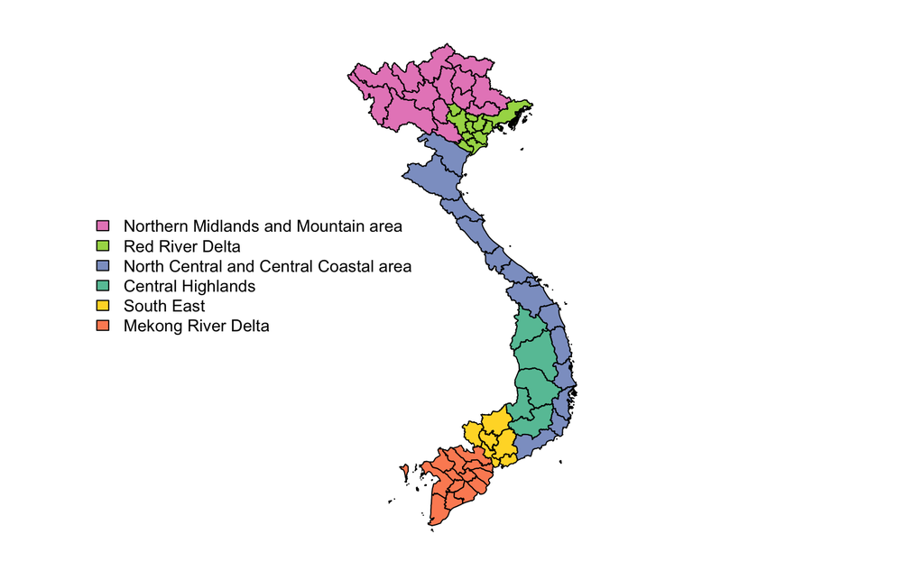

```r
left_join(provinces,
          data.frame(VARNAME_1 = approxmatching$matched,
                     region = sub("\\d+", "", rownames(approxmatching)),
                     stringsAsFactors = FALSE), by = "VARNAME_1") %>%
  select(region) %>%
  plot(main = NA, key.pos = NULL)
legend("left", legend = regions[c(2, 1, 3:6)],
       fill = sf.colors(6, categorical = TRUE)[c(4, 5, 3, 1, 6, 2)], bty = "n")
```

## Preparing the data

The function below removes the attributes of all the variables of a data frame, which is required before the `gather()` calls:

```r
remove_attributes <- function(df) {
  require(magrittr)
  df %>%
    lapply(`attributes<-`, NULL) %>%
    as.data.frame()
}
```

### Calculating the number of doses for each vaccine

In the MiCS data we have information for 8 vaccines – of which we will study the MOV –, as well as 2 vitamin A shots (that will be considered for the computation of the MOVs). The number of doses indicated in the table below are the required number of doses. Note that these required numbers of doses are expected to be given by the age of 1 year-old.

| vaccine | MICS code | number of doses |
| --- | --- | --- |
| BCG | B | 1 |
| Polio | P1, P2, P3 | 3 |
| *Haemophilus influenzae* type B | I1, I2, I3 | 3 |
| Hepatitis B at birth | H0 | 1 |
| Hepatitis B | H1, H2, H3 | 3 |
| MMR (measles + mumps + rubeola) | M | 1 |
| DTP (dipheteria + tetanus + pertussis) | D1, D2, D3 | 3 |
| Pentavalent (DTP + hepatitis B + *Haemophilus influenzae* type B) | PEN1, PEN2, PEN3 | 3 |
| Vitamin A first dose | V1 | 1 |
| Vitamin A second dose | V2 | 1 |

In the MICS data, the information for each vaccine dose is coded by 3 column: the day, the month and the year of the shot. There are also code for missing values. These codes are:

```r
attr(ch$IM3BD, "labels")
```

```
##       Not given  Marked on card Mother reported    Inconsistent              DK         Missing
##               0              44              66              97              98              99
```

Note that there are also true missing values in these columns (in the same that both date information and missing value code are missing):

```r
any(is.na(ch$IM3BD))
```

```
## [1] TRUE
```

The function `nbdoses()` considers that there was absence of shot when the YMD date of the vaccine was `NA-NA-NA`, `NA-NA-0`, or `0-0-0`. Everything else was interpreted as presence of vaccination. Note that

- `H0` has to be distinguished from the 3 doses of `H`: `H1`, `H2` and `H3`;
- `V1` and `V2` shouldn’t be combined as if there were doses of a same vaccine.

Here is the code of the `nbdoses()` function where `df` is a MICS children table and `pattern` is the pattern that characterize the vaccines columns:

```r
nbdoses <- function(df, pattern) {
  require(dplyr)
  require(tidyr)
  df %>%
    select(matches(pattern)) %>%
    mutate(id = row_number()) %>%
    remove_attributes() %>% # needed by the gather() call that follows
    gather("key", "value", -id) %>%
    mutate(vaccine = sub("(.*).$", "\\1", key),
           time = sub(".*(.)$", "\\1", key)) %>%
    select(-key) %>%
    spread(time, value) %>%
    unite("date", Y, M, D) %>%
    mutate_at("date", na_if, "NA_NA_NA") %>% # here we specify the cases
    mutate_at("date", na_if, "NA_NA_0") %>%  # that are considered as
    mutate_at("date", na_if, "0_0_0") %>%    # absence of vaccination
    mutate_at("date", ~!is.na(.)) %>%        # (this has been checked).
    mutate(vaccine = vaccine %>%
             sub("(.*H0)", "\\10", .) %>% # to protect H0 (that is different from H)
             sub("(.*V\\d)", "\\10", .) %>% # to protect vitamins (that are use to compute MOVs)
             sub("\\d$", "", .)) %>%
    group_by(id, vaccine) %>%
    summarise(n = sum(date)) %>%
    ungroup() %>%
    spread(vaccine, n) %>%
    select(-id)
}
```

Let’s try an example:

```r
nbdoses(ch, "^IM3|^HF13")
```

```
## # A tibble: 3,346 x 20
##    HF13B HF13D HF13H HF13H0 HF13I HF13M HF13P HF13PEN HF13V1 HF13V2  IM3B  IM3D  IM3H IM3H0  IM3I  IM3M  IM3P IM3PEN IM3V1 IM3V2
##    <int> <int> <int>  <int> <int> <int> <int>   <int>  <int>  <int> <int> <int> <int> <int> <int> <int> <int>  <int> <int> <int>
##  1     0     0     0      0     0     0     0       0      0      0     1     0     0     1     0     1     3      3     0     0
##  2     0     0     0      0     0     0     0       0      0      0     1     0     0     1     0     0     3      3     0     0
##  3     1     0     1      0     0     1     0       3      0      0     1     0     0     1     0     1     3      3     0     0
##  4     1     3     3      1     3     1     3       0      0      0     1     3     3     1     3     1     3      0     0     0
##  5     0     0     0      0     0     0     0       0      0      0     1     0     0     1     0     1     3      3     0     0
##  6     1     0     0      0     0     1     3       3      0      0     1     0     0     1     0     1     3      3     0     0
##  7     0     0     0      0     0     0     0       0      0      0     1     0     0     1     0     1     3      3     0     0
##  8     0     0     0      0     0     0     0       0      0      0     0     0     0     0     0     0     0      0     0     0
##  9     0     0     0      0     0     0     0       0      0      0     1     0     0     1     0     1     3      3     0     0
## 10     0     0     0      0     0     0     0       0      0      0     0     0     0     0     0     0     0      0     0     0
## # … with 3,336 more rows
```

The function `combine_series()` below works on an output of the previous function and combines the numbers of doses from 2 series. The combination is obvious when the number of doses from one series are 0 or when the numbers of doses from the 2 series are identical. In other situation, it is not clear what we should do. The function `nbdoses_selection()` below is used by `combine_series()` and is the one that deals with the choices on the numbers of doses when we combine the 2 series. The choice is regulated by the arguments `exclude_inconsistencies` and `keep_min`:

- if `exclude_inconsistencies = TRUE` all inconsistencies are excluded and the final number of doses for this vaccine will be `NA`
- if `exclude_inconsistencies = FALSE` then
  - if `keep_min = TRUE` the smallest number of doses between the 2 series is considered.
  - if `keep_min = FALSE` the largest number of doses between the 2 series is considered.

```r
nbdoses_selection <- function(df, exclude_inconsistencies = TRUE, keep_min = TRUE) {
  require(dplyr)
  if (exclude_inconsistencies) return(mutate(filter(df, series1 == series2), nb_doses = series1))
  if (keep_min) return(mutate(df, nb_doses = ifelse(series1 < series2, series1, series2)))
  mutate(df, nb_doses = ifelse(series1 > series2, series1, series2))
}
```

Here is the code of the `combine_series()` function that uses the `nbdoses_seletion()` function:

```r
combine_series <- function(df, pattern, exclude_inconsistencies = TRUE, keep_min = TRUE) {
  require(dplyr)
  require(tidyr)
  df %>%
    mutate(id = row_number()) %>%
    remove_attributes() %>% # needed by the gather() call that follows
    gather("key", "value", -id) %>%
    mutate(series  = sub(paste0("(", pattern, ").*"), "\\1", key),
           vaccine = sub(pattern, "", key)) %>%
    select(-key) %>%
    group_by(vaccine, id) %>%
    spread(series, value) %>%
    ungroup() %>%
    setNames(c("id", "vaccine", "series1", "series2")) %>% # for the nbdoses_selection() call that follows
    nbdoses_selection(exclude_inconsistencies, keep_min) %>%
    select(-series1, -series2) %>%
    spread(vaccine, nb_doses) %>%
    select(-id)
}
```

Let’s try it when replacing all inconsistencies by NAs:

```r
ch %>%
  nbdoses("^IM3|^HF13") %>%
  combine_series("^IM3|^HF13")
```

```
## # A tibble: 3,346 x 10
##        B     D     H    H0     I     M     P   PEN    V1    V2
##    <int> <int> <int> <int> <int> <int> <int> <int> <int> <int>
##  1    NA     0     0    NA     0    NA    NA    NA     0     0
##  2    NA     0     0    NA     0     0    NA    NA     0     0
##  3     1     0    NA    NA     0     1    NA     3     0     0
##  4     1     3     3     1     3     1     3     0     0     0
##  5    NA     0     0    NA     0    NA    NA    NA     0     0
##  6     1     0     0    NA     0     1     3     3     0     0
##  7    NA     0     0    NA     0    NA    NA    NA     0     0
##  8     0     0     0     0     0     0     0     0     0     0
##  9    NA     0     0    NA     0    NA    NA    NA     0     0
## 10     0     0     0     0     0     0     0     0     0     0
## # … with 3,336 more rows
```

Considering the minimal value in case of inconsistency:

```r
ch %>%
  nbdoses("^IM3|^HF13") %>%
  combine_series("^IM3|^HF13", FALSE)
```

```
## # A tibble: 3,346 x 10
##        B     D     H    H0     I     M     P   PEN    V1    V2
##    <int> <int> <int> <int> <int> <int> <int> <int> <int> <int>
##  1     0     0     0     0     0     0     0     0     0     0
##  2     0     0     0     0     0     0     0     0     0     0
##  3     1     0     0     0     0     1     0     3     0     0
##  4     1     3     3     1     3     1     3     0     0     0
##  5     0     0     0     0     0     0     0     0     0     0
##  6     1     0     0     0     0     1     3     3     0     0
##  7     0     0     0     0     0     0     0     0     0     0
##  8     0     0     0     0     0     0     0     0     0     0
##  9     0     0     0     0     0     0     0     0     0     0
## 10     0     0     0     0     0     0     0     0     0     0
## # … with 3,336 more rows
```

Considering the maximal value in case of inconsistency:

```r
ch %>%
  nbdoses("^IM3|^HF13") %>%
  combine_series("^IM3|^HF13", FALSE, FALSE)
```

```
## # A tibble: 3,346 x 10
##        B     D     H    H0     I     M     P   PEN    V1    V2
##    <int> <int> <int> <int> <int> <int> <int> <int> <int> <int>
##  1     1     0     0     1     0     1     3     3     0     0
##  2     1     0     0     1     0     0     3     3     0     0
##  3     1     0     1     1     0     1     3     3     0     0
##  4     1     3     3     1     3     1     3     0     0     0
##  5     1     0     0     1     0     1     3     3     0     0
##  6     1     0     0     1     0     1     3     3     0     0
##  7     1     0     0     1     0     1     3     3     0     0
##  8     0     0     0     0     0     0     0     0     0     0
##  9     1     0     0     1     0     1     3     3     0     0
## 10     0     0     0     0     0     0     0     0     0     0
## # … with 3,336 more rows
```

### Computing MOVs

Below are the missed opportunities of vaccination (MOVs) that we will consider:

| vaccine | missed opportunity with | code |
| --- | --- | --- |
| BCG | post-natal check | mov1 |
| hepatitis B at birth | post-natal check | mov2 |
| polio | non-campaign vitamin A | mov4 |
| measles | non-campaign vitamin A | mov6 |
| polio | campaign vitamin A | mov8 |
| measles | campaign vitamin A | mov10 |
| polio | curative care | mov12 |
| measles | curative care | mov14 |
| DTP (diphteria, tetanus, rubeola) | non-campaign vitamin A | mov15 |
| DTP (diphteria, tetanus, rubeola) | curative care | mov16 |
| DTP (diphteria, tetanus, rubeola) | campaign vitamin A | mov17 |
| DTP or polio or BCG | measles | mov18 |
| BCG or hepatitis B at birth | post-natal check | mov_nn |
| polio or measles or DTP | non-campaign vitamin A | mov_pc |
| polio or measles or DTP | campaign vitamin A | mov_ca |
| polio or measles or DTP | currative care | mov_cc |

The following function returns whether there has been a missed opportunity of vaccination which is the absence of vaccination in the presence of care. This rule needs to be protected so that `NA` instead of `FALSE` is returned when one of care and vaccination is `NA` and the other one `FALSE`.

```r
mov <- function(care, vacc) {
  if_else(is.na(care) | is.na(vacc), NA, care & ! vacc)
}
```

### Data preparation pipeline

```r
recode2 <- function(x) {
  labels <- attr(x, "labels")
  unname(setNames(names(labels), labels)[as.character(x)])
}
```

Questions:

- how are missing values dealt with for vitamin A?
- how are missing values dealt with for vaccine shots?

The pipeline function:

```r
data_preparation <- function(df, pattern = "^IM3|^HF13", exclude_inconsistencies = TRUE, keep_min = TRUE) {
  df %>%
# 0 - computes vaccines doses:
    (function(x) lapply(list(function(y) select(y, -matches(pattern)),
                             function(y) combine_series(nbdoses(y, pattern), pattern, exclude_inconsistencies, keep_min)),
                        function(f) f(x))) %>%
    bind_cols() %>%
# 1 - replacing DK and missing by NAs:
    mutate(IM19A   = na_if(IM19A, 8), IM19A = na_if(IM19A, 9), # Vitamin A campaign in June 2013
           IM19B   = na_if(IM19B, 8), IM19B = na_if(IM19B, 9), # Vitamin A campaign in December 2012/2013
           melevel = na_if(melevel, 9), # Mother's education level
# 2 - curative care:
           curative_care = trimws(paste(CA11A, CA11B, CA11C, CA11E, CA11F, CA11I, CA11J,
                                        CA3BA, CA3BB, CA3BC, CA3BE, CA3BF, CA3BI, CA3BJ)) != "",
# 3 - post-natal check:
           post_natal_check = ifelse(PN13A == "" & PN13B == "",
                                     FALSE,
                                     ifelse(PN13A == "?" & PN13B == "?",
                                            NA,
                                            TRUE)),
# 4 - delivery:
           delivery = ifelse(MN18 < 13,
                             "home",
                             ifelse(MN18 > 13 & MN18 < 27,
                                    "public",
                                    ifelse(MN18 > 27 & MN18 < 37,
                                           "private",
                                           NA))),
# 5 - computing vaccination:
           PEND = coalesce(PEN, 0L) + coalesce(D, 0L) > 2) %>% # DTP
    mutate_at(c("B", "H0", "I", "M"), `>`, 0) %>% # NA are kept NA
    mutate_at(c("D", "H", "P", "PEN"), `>`, 2) %>% # NA are kept NA
    mutate_at(vars(starts_with("IM19")), `<`, 2) %>% # Vit A campaigns: DK and missing are considered FALSE
    mutate_at(vars(starts_with("V")), `>`, 0) %>% # non-campaign vitamin A
# 6 - computing MOVs:
    mutate(mov1   = mov(post_natal_check, B), # BCG
           mov2   = mov(post_natal_check, H0), # hepatitis B at birth
           mov4   = mov(V1, P), # polio with non-campaign vitamin A
           mov6   = mov(V2, M), # measles with non-campaign vitamin A
           mov8   = mov(IM19B, P), # polio with campaign vitamin A
           mov10  = mov(IM19A, M), # measles with campaign vitamin A
           mov12  = mov(curative_care, P), # polio
           mov14  = mov(curative_care, M), # measles
           mov15  = mov(V1, PEND), # DTP (diphteria, tetanus, rubeola) with non-campaign vitamin A
           mov16  = mov(curative_care, PEND), # DTP (diphteria, tetanus, rubeola)
           mov17  = mov(IM19B, PEND), # DTP (diphteria, tetanus, rubeola) with campaign vitamin A
           mov18  = mov(M, apply(! select(., B, P, PEND), 1, any)), # received measles but at least one of DTP, polio and BCG is missing
           mov_nn = mov1 | mov2, # BCG ou hepatitis B at birth with post-natal check
           mov_pc = mov4 | mov6 | mov15, # polio or measles or DTP with non-campaign vitamin A
           mov_ca = mov8 | mov10 | mov17, # polio or measles or DTP with campaign vitamin A
           mov_cc = mov12 | mov14 | mov16 | mov18, # polio or measles or DTP with curative care or DTP or polio or BCG with measles
           vaccine_status = B & M & PEND & P) %>% # has vaccination against DTP, polio, BCG and measles
    mutate(mov_any  = select(., matches("^mov\\d"))        %>% apply(1, any), # has to be in a separate mutate call because relies on the whole data frame
           mov_any2 = select(., matches("^mov\\d"), -mov2) %>% apply(1, any)) %>%
# 7 - recoding "independent" variables:
    mutate_at(c("HH6", "HH7", "melevel", "ethnicity", "windex5", "HL4", "MT0"), recode2) %>%
# 8 - selecting variables:
    select(starts_with("mov"), vaccine_status, starts_with("HH"), "chweight",
           "delivery", "melevel", "ethnicity", "windex5", "HL4", "WB2", "MT0", "AG2") %>%
# 9 - converting to a survey design object:
    survey::svydesign(~ HH1 + HH2, strata = ~ HH6 + HH7, weights = ~ chweight, data = .)
}
```

Let’s generate the data:

```r
mics_survey <- data_preparation(mics, pattern = "^IM3|^HF13", exclude_inconsistencies = TRUE, keep_min = TRUE)
```

## Analyses

### Proportions of children completely vaccinated

Let’s estimate the proportions of children that are fully vaccinated per age class, region and area type. The number of children per age class is:

```r
mics_survey$variables %>%
   group_by(AG2) %>%
   tally()
```

```
## # A tibble: 6 x 2
##     AG2     n
##   <dbl> <int>
## 1     0   718
## 2     1   780
## 3     2   633
## 4     3   550
## 5     4   635
## 6    NA    30
```

The number of children per region is:

```r
mics_survey$variables %>%
   group_by(HH7) %>%
   tally()
```

```
## # A tibble: 6 x 2
##   HH7                                        n
##   <chr>                                  <int>
## 1 Central Highlands                        673
## 2 Mekong River Delta                       493
## 3 North Central and Central Coastal area   495
## 4 Northern Midlands and Mountain area      644
## 5 Red River Delta                          520
## 6 South East                               521
```

The number of children per environment is:

```r
mics_survey$variables %>%
   group_by(HH6) %>%
   tally()
```

```
## # A tibble: 2 x 2
##   HH6       n
##   <chr> <int>
## 1 Rural  2072
## 2 Urban  1274
```

Note that

```r
svyby(~ vaccine_status, ~ AG2, mics_survey, svyciprop)
```

doesn’t work. Let’s consider the following function instead:

```r
proportions <- function(svy, var, name) {
  require(rlang)
  require(dplyr)
  nb <- na.exclude(tally(group_by(svy$variables, !!eval(enquo(var)))))
# the sort() below is need because the group_by() above does sorting
  lapply(sort(na.exclude(unlist(unique(select(svy$variables, !!eval(enquo(var))))))),
         function(x)
           svyciprop(~ vaccine_status, subset(svy, !!eval(enexpr(var)) == x)) %>%
             c(., attr(., "ci")) %>%
             matrix(1) %>%
             as.data.frame()) %>%
    bind_rows() %>%
    `*`(100) %>%
    round(2) %>%
    cbind(nb, .) %>%
    `names<-`(c(name, "n", "proportion", "2.5%", "97.5%"))
}
```

That we can use to calculate the proportion of fully vaccinated children per age class:

```r
proportions(mics_survey, AG2, "age")
```

```
##   age   n proportion  2.5% 97.5%
## 1   0 718       2.31  1.34  3.95
## 2   1 780      55.10 50.50 59.61
## 3   2 633      43.29 38.44 48.28
## 4   3 550       0.00  0.00  0.00
## 5   4 635       0.00  0.00  0.00
```

Per region:

```r
mics_survey %>%
  proportions(HH7, "region") %>%
  arrange(proportion)
```

```
##                                   region   n proportion  2.5% 97.5%
## 1    Northern Midlands and Mountain area 644      13.00  9.31 17.86
## 2                      Central Highlands 673      17.04 13.48 21.32
## 3                             South East 521      18.20 14.32 22.84
## 4                     Mekong River Delta 493      23.46 19.73 27.66
## 5 North Central and Central Coastal area 495      24.64 20.93 28.76
## 6                        Red River Delta 520      26.34 21.69 31.57
```

And per environment:

```r
proportions(mics_survey, HH6, "environment")
```

```
##   environment    n proportion  2.5% 97.5%
## 1       Rural 2072      21.69 19.33 24.25
## 2       Urban 1274      20.95 18.31 23.85
```

### Proportions of 1-2 year-old children with MOV

From now on, we’ll consider the following subset of children:

```r
mics_survey2 <- subset(mics_survey, AG2 == 1)
```

In order to account for potential non-linearity of the effect of mother’s age, let’s discretize this variable:

```r
if (length(unique(mics_survey2$variables$WB2)) > 3)
  mics_survey2$variables$WB2 %<>%
    cut(., quantile(., seq(0, 1, le = 4), TRUE), include.lowest = TRUE) %>%
    as.character()
```

Note that we convert it into character, as are all the other “independent” variables. This is better in order to use the `svyglm2()` function below. Here are the MOV variables that we’ll consider:

```r
(y <- grep("mov", names(mics_survey2$variables), value = TRUE))
```

```
##  [1] "mov1"     "mov2"     "mov4"     "mov6"     "mov8"     "mov10"    "mov12"    "mov14"    "mov15"    "mov16"    "mov17"    "mov18"
## [13] "mov_nn"   "mov_pc"   "mov_ca"   "mov_cc"   "mov_any"  "mov_any2"
```

The following function builds a formula from a vector `x` of names of explanatory variables and the name `y` of a dependent variable:

```r
make_formula <- function(x, y) as.formula(paste(y, "~", paste(x, collapse = " + ")))
```

For each of these MOVs, let’s estimate the propotion of 1-2 year-old children it affects:

```r
y %>%
  lapply(function(x)
           svyciprop(make_formula(x, ""), mics_survey2) %>%
             c(., attr(., "ci")) %>%
             matrix(1) %>%
             as.data.frame()) %>%
  bind_rows() %>%
  `*`(100) %>%
  round(2) %>%
  bind_cols(data.frame(MOV = y, stringsAsFactors = FALSE), .) %>%
  `names<-`(c("MOV", "proportion", "2.5%", "97.5%")) %>%
  arrange(desc(proportion))
```

```
##         MOV proportion  2.5% 97.5%
## 1   mov_any      97.68 96.23 98.58
## 2  mov_any2      97.28 95.77 98.26
## 3    mov_cc      86.59 83.20 89.38
## 4     mov18      71.38 66.58 75.75
## 5    mov_ca      34.79 30.70 39.12
## 6     mov17      29.13 25.53 33.02
## 7     mov16      14.56 12.09 17.43
## 8     mov10       9.74  7.32 12.84
## 9    mov_nn       8.02  5.59 11.37
## 10     mov2       7.05  4.93  9.99
## 11     mov8       6.57  4.60  9.29
## 12    mov14       5.94  4.15  8.42
## 13    mov12       3.44  2.13  5.52
## 14     mov1       1.71  0.87  3.34
## 15   mov_pc       0.41  0.06  2.89
## 16     mov4       0.38  0.05  2.62
## 17    mov15       0.25  0.04  1.78
## 18     mov6       0.00  0.00  0.00
```

Note that there are no MOV6. We’ll thus remove them from the analyses below:

```r
y2 <- setdiff(y, "mov6")
```

### Logistic models

In these section, we use logistic model in order to explain the presence of MOV as a function of the following variables:

```r
x <- c("HH6", "HH7", "delivery", "melevel", "ethnicity", "windex5", "HL4", "WB2", "MT0")
```

#### Identification of confounders

A variable can be considered as a confounder if it’s not independent of the exposure. Thus, a first step in narrowing potential confounders is to generate a matrix of independence between all pairs of independent variables. This can be done by Wald tests on contingency tables in order to generate pairwise matrix of independence as done below. This is preferable to a logistic regression as it allows to test relationships between categorical variables of any number of levels.

```r
nb <- length(x)
x_mat <- matrix(numeric(nb * nb), nb, dimnames = list(x, x))
for(i in 1:nb)
  for(j in setdiff(1:nb, i))
    x_mat[i, j] <- svychisq(make_formula(c(x[i], x[j]), ""), mics_survey2, "Wald")$p.value
```

The matrix looks like:

```r
round(x_mat, 4)
```

```
##              HH6    HH7 delivery melevel ethnicity windex5    HL4    WB2    MT0
## HH6       0.0000 0.0012   0.0002  0.0001    0.0002  0.0000 0.9288 0.0000 0.0001
## HH7       0.0012 0.0000   0.0000  0.0000    0.0000  0.0000 0.1391 0.0000 0.0000
## delivery  0.0002 0.0000   0.0000  0.0019    0.0001  0.0014 0.0307 0.2670 0.0001
## melevel   0.0001 0.0000   0.0019  0.0000    0.0001  0.0000 0.4610 0.0017 0.0000
## ethnicity 0.0002 0.0000   0.0001  0.0001    0.0000  0.0000 0.5099 0.0001 0.0000
## windex5   0.0000 0.0000   0.0014  0.0000    0.0000  0.0000 0.9385 0.0000 0.0000
## HL4       0.9288 0.1391   0.0307  0.4610    0.5099  0.9385 0.0000 0.0950 0.0177
## WB2       0.0000 0.0000   0.2670  0.0017    0.0001  0.0000 0.0950 0.0000 0.0041
## MT0       0.0001 0.0000   0.0001  0.0000    0.0000  0.0000 0.0177 0.0041 0.0000
```

```r
alpha <- .05
x_mat < (2 * alpha / (nb^2 - nb))
```

```
##             HH6   HH7 delivery melevel ethnicity windex5   HL4   WB2   MT0
## HH6        TRUE  TRUE     TRUE    TRUE      TRUE    TRUE FALSE  TRUE  TRUE
## HH7        TRUE  TRUE     TRUE    TRUE      TRUE    TRUE FALSE  TRUE  TRUE
## delivery   TRUE  TRUE     TRUE   FALSE      TRUE   FALSE FALSE FALSE  TRUE
## melevel    TRUE  TRUE    FALSE    TRUE      TRUE    TRUE FALSE FALSE  TRUE
## ethnicity  TRUE  TRUE     TRUE    TRUE      TRUE    TRUE FALSE  TRUE  TRUE
## windex5    TRUE  TRUE    FALSE    TRUE      TRUE    TRUE FALSE  TRUE  TRUE
## HL4       FALSE FALSE    FALSE   FALSE     FALSE   FALSE  TRUE FALSE FALSE
## WB2        TRUE  TRUE    FALSE   FALSE      TRUE    TRUE FALSE  TRUE FALSE
## MT0        TRUE  TRUE     TRUE    TRUE      TRUE    TRUE FALSE FALSE  TRUE
```

Thus, among our independent variables, only the sex of the child (`HL4`) can be ruled out at this stage as a potential confounder. A second condition for a variable to be considered as a potential confounder is that it should be non-independent of the outcome. For that, we can proceed as done above:

```r
non_corrected <- sapply(y2, function(j)
                              sapply(x, function(i)
                                svychisq(make_formula(c(i, j), ""),
                                         mics_survey2,
                                         "Wald")$p.value))
```

Which gives:

```r
round(non_corrected, 4)
```

```
##             mov1   mov2   mov4   mov8  mov10  mov12  mov14  mov15  mov16  mov17  mov18 mov_nn mov_pc mov_ca mov_cc mov_any mov_any2
## HH6       0.8398 0.9701 0.3157 0.2052 0.0539 0.1804 0.2412 0.3154 0.6928 0.3550 0.1748 0.7939 0.3174 0.2176 0.6276  0.2456   0.1969
## HH7       0.0522 0.1896 0.9613 0.1588 0.4110 0.2073 0.8349 0.9612 0.5061 0.0727 0.0060 0.1142 0.9619 0.0376 0.0200  0.0043   0.0010
## delivery  0.0579 0.0083 0.6202 0.6918 0.2019 0.9056 0.4599 0.6208 0.6150 0.4164 0.0059 0.0087 0.6174 0.2898 0.0010  0.0087   0.0058
## melevel   0.6698 0.4161 0.9074 0.7819 0.1999 0.2418 0.2264 0.9079 0.7843 0.3094 0.0067 0.5792 0.9085 0.1390 0.0020  0.0072   0.0026
## ethnicity 0.9416 0.7390 0.3196 0.5528 0.0792 0.4168 0.1692 0.3195 0.7376 0.7928 0.0027 0.6918 0.3216 0.3353 0.0022  0.0106   0.0060
## windex5   0.6286 0.6259 0.9076 0.8143 0.0155 0.4396 0.0014 0.9067 0.9299 0.9512 0.0358 0.6781 0.9085 0.8905 0.0064  0.0113   0.0028
## HL4       0.9200 0.9150 0.3154 0.3715 0.7924 0.9451 0.8138 0.3150 0.2571 0.2146 0.2817 0.8459 0.3171 0.2805 0.9993  0.6550   0.6810
## WB2       0.9388 0.1992 0.6029 0.5475 0.7665 0.6881 0.2825 0.6044 0.0320 0.1949 0.2020 0.2048 0.6050 0.0383 0.4850  0.0806   0.0959
## MT0       0.7517 0.2225 0.3190 0.0767 0.8901 0.3387 0.3125 0.3186 0.4065 0.1654 0.0056 0.3876 0.3206 0.4325 0.0011  0.0008   0.0005
```

Thus, now, the potential confounders, for each MOV, are:

```r
(pot_conf <- lapply(as.data.frame(non_corrected),
                    function(x) setdiff(rownames(non_corrected)[which(x < .1)], "HL4")))
```

```
## $mov1
## [1] "HH7"      "delivery"
##
## $mov2
## [1] "delivery"
##
## $mov4
## character(0)
##
## $mov8
## [1] "MT0"
##
## $mov10
## [1] "HH6"       "ethnicity" "windex5"
##
## $mov12
## character(0)
##
## $mov14
## [1] "windex5"
##
## $mov15
## character(0)
##
## $mov16
## [1] "WB2"
##
## $mov17
## [1] "HH7"
##
## $mov18
## [1] "HH7"       "delivery"  "melevel"   "ethnicity" "windex5"   "MT0"
##
## $mov_nn
## [1] "delivery"
##
## $mov_pc
## character(0)
##
## $mov_ca
## [1] "HH7" "WB2"
##
## $mov_cc
## [1] "HH7"       "delivery"  "melevel"   "ethnicity" "windex5"   "MT0"
##
## $mov_any
## [1] "HH7"       "delivery"  "melevel"   "ethnicity" "windex5"   "WB2"       "MT0"
##
## $mov_any2
## [1] "HH7"       "delivery"  "melevel"   "ethnicity" "windex5"   "WB2"       "MT0"
```

Note above that we exclude `HL4` from all the potential confounders. Last step is to rerun all these models, this time correcting for potential confoundings.

#### Models correcting for potential confounding effects

The following function implements a partial likelihood ratio test (LRT) and returns the corresponding p value:

```r
corrected_p_value <- function(x, y) {
  make_formula(c(setdiff(pot_conf[[y]], x), x), y) %>% # adding potential confounders
    svyglm(mics_survey2, family = quasibinomial) %>%  # runing binomial regression
    anova(., update(., make_formula(paste(". - ", x), ".")), test = "Chisq") %>% # partial LRT
    `$`("p")
}
```

Note here that, because of the `update()` call, we cannot put the family and the design as arguments of the function. We chose not to include the `pot_conf` object either. Let’s try it:

```r
corrected_p_value(x[1], y[1])
```

```
## [1] 0.8113129
```

Let’s now apply it to all the independent and dependent varibles realationships that need to be corrected:

```r
corrected <- non_corrected
with_confounders <- names(which(sapply(pot_conf, length) > 0))
corrected[, with_confounders] <- sapply(with_confounders,
                                        function(y) sapply(x, corrected_p_value, y = y))
```

which gives:

```r
round(corrected, 4)
```

```
##             mov1   mov2   mov4   mov8  mov10  mov12  mov14  mov15  mov16  mov17  mov18 mov_nn mov_pc mov_ca mov_cc mov_any mov_any2
## HH6       0.8113 0.9558 0.3157 0.5190 0.1551 0.1804 0.6559 0.3154 0.6673 0.4054 0.1032 0.8731 0.3174 0.2472 0.1588  0.7732   0.5439
## HH7       0.2377 0.2437 0.9613 0.0513 0.6688 0.2073 0.8824 0.9612 0.4922 0.0550 0.0274 0.2100 0.9619 0.0327 0.1231  0.0000   0.0000
## delivery  0.1192 0.0037 0.6202 0.0014 0.0000 0.9056 0.0050 0.6208 0.0379 0.0000 0.0175 0.0043 0.6174 0.0337 0.0045  0.0006   0.0013
## melevel   0.6296 0.3727 0.9074 0.6833 0.6461 0.2418 0.3429 0.9079 0.7171 0.3726 0.6851 0.4463 0.9085 0.1502 0.6430  0.0244   0.0785
## ethnicity 0.8127 0.9101 0.3196 0.1132 0.1039 0.4168 0.1835 0.3195 0.5737 0.1605 0.9621 0.6345 0.3216 0.4856 0.6161  0.1043   0.0943
## windex5   0.4690 0.6198 0.9076 0.7719 0.2264 0.4396 0.0021 0.9067 0.7224 0.7909 0.4691 0.6623 0.9085 0.8173 0.2472  0.0781   0.0408
## HL4       0.9126 0.7777 0.3154 0.4046 0.7296 0.9451 0.8038 0.3150 0.3766 0.2264 0.7195 0.7414 0.3171 0.4621 0.3470  0.5448   0.6564
## WB2       0.9447 0.1690 0.6029 0.4358 0.0002 0.6881 0.1316 0.6044 0.0002 0.0000 0.2145 0.2164 0.6050 0.0000 0.5750  0.0722   0.2305
## MT0       0.6581 0.4402 0.3190 0.0000 0.0000 0.3387 0.0780 0.3186 0.2288 0.0000 0.3146 0.4850 0.3206 0.1483 0.0499  0.0012   0.0047
```

to be compared with:

```r
round(non_corrected, 4)
```

```
##             mov1   mov2   mov4   mov8  mov10  mov12  mov14  mov15  mov16  mov17  mov18 mov_nn mov_pc mov_ca mov_cc mov_any mov_any2
## HH6       0.8398 0.9701 0.3157 0.2052 0.0539 0.1804 0.2412 0.3154 0.6928 0.3550 0.1748 0.7939 0.3174 0.2176 0.6276  0.2456   0.1969
## HH7       0.0522 0.1896 0.9613 0.1588 0.4110 0.2073 0.8349 0.9612 0.5061 0.0727 0.0060 0.1142 0.9619 0.0376 0.0200  0.0043   0.0010
## delivery  0.0579 0.0083 0.6202 0.6918 0.2019 0.9056 0.4599 0.6208 0.6150 0.4164 0.0059 0.0087 0.6174 0.2898 0.0010  0.0087   0.0058
## melevel   0.6698 0.4161 0.9074 0.7819 0.1999 0.2418 0.2264 0.9079 0.7843 0.3094 0.0067 0.5792 0.9085 0.1390 0.0020  0.0072   0.0026
## ethnicity 0.9416 0.7390 0.3196 0.5528 0.0792 0.4168 0.1692 0.3195 0.7376 0.7928 0.0027 0.6918 0.3216 0.3353 0.0022  0.0106   0.0060
## windex5   0.6286 0.6259 0.9076 0.8143 0.0155 0.4396 0.0014 0.9067 0.9299 0.9512 0.0358 0.6781 0.9085 0.8905 0.0064  0.0113   0.0028
## HL4       0.9200 0.9150 0.3154 0.3715 0.7924 0.9451 0.8138 0.3150 0.2571 0.2146 0.2817 0.8459 0.3171 0.2805 0.9993  0.6550   0.6810
## WB2       0.9388 0.1992 0.6029 0.5475 0.7665 0.6881 0.2825 0.6044 0.0320 0.1949 0.2020 0.2048 0.6050 0.0383 0.4850  0.0806   0.0959
## MT0       0.7517 0.2225 0.3190 0.0767 0.8901 0.3387 0.3125 0.3186 0.4065 0.1654 0.0056 0.3876 0.3206 0.4325 0.0011  0.0008   0.0005
```

Filtering out the significant relationships:

```r
alpha <- .05
corrected < alpha
```

```
##            mov1  mov2  mov4  mov8 mov10 mov12 mov14 mov15 mov16 mov17 mov18 mov_nn mov_pc mov_ca mov_cc mov_any mov_any2
## HH6       FALSE FALSE FALSE FALSE FALSE FALSE FALSE FALSE FALSE FALSE FALSE  FALSE  FALSE  FALSE  FALSE   FALSE    FALSE
## HH7       FALSE FALSE FALSE FALSE FALSE FALSE FALSE FALSE FALSE FALSE  TRUE  FALSE  FALSE   TRUE  FALSE    TRUE     TRUE
## delivery  FALSE  TRUE FALSE  TRUE  TRUE FALSE  TRUE FALSE  TRUE  TRUE  TRUE   TRUE  FALSE   TRUE   TRUE    TRUE     TRUE
## melevel   FALSE FALSE FALSE FALSE FALSE FALSE FALSE FALSE FALSE FALSE FALSE  FALSE  FALSE  FALSE  FALSE    TRUE    FALSE
## ethnicity FALSE FALSE FALSE FALSE FALSE FALSE FALSE FALSE FALSE FALSE FALSE  FALSE  FALSE  FALSE  FALSE   FALSE    FALSE
## windex5   FALSE FALSE FALSE FALSE FALSE FALSE  TRUE FALSE FALSE FALSE FALSE  FALSE  FALSE  FALSE  FALSE   FALSE     TRUE
## HL4       FALSE FALSE FALSE FALSE FALSE FALSE FALSE FALSE FALSE FALSE FALSE  FALSE  FALSE  FALSE  FALSE   FALSE    FALSE
## WB2       FALSE FALSE FALSE FALSE  TRUE FALSE FALSE FALSE  TRUE  TRUE FALSE  FALSE  FALSE   TRUE  FALSE   FALSE    FALSE
## MT0       FALSE FALSE FALSE  TRUE  TRUE FALSE FALSE FALSE FALSE  TRUE FALSE  FALSE  FALSE  FALSE   TRUE    TRUE     TRUE
```

Applying a multiple tests correction:

```r
(mt_correction <- corrected < alpha / prod(dim(corrected)))
```

```
##            mov1  mov2  mov4  mov8 mov10 mov12 mov14 mov15 mov16 mov17 mov18 mov_nn mov_pc mov_ca mov_cc mov_any mov_any2
## HH6       FALSE FALSE FALSE FALSE FALSE FALSE FALSE FALSE FALSE FALSE FALSE  FALSE  FALSE  FALSE  FALSE   FALSE    FALSE
## HH7       FALSE FALSE FALSE FALSE FALSE FALSE FALSE FALSE FALSE FALSE FALSE  FALSE  FALSE  FALSE  FALSE    TRUE     TRUE
## delivery  FALSE FALSE FALSE FALSE  TRUE FALSE FALSE FALSE FALSE  TRUE FALSE  FALSE  FALSE  FALSE  FALSE   FALSE    FALSE
## melevel   FALSE FALSE FALSE FALSE FALSE FALSE FALSE FALSE FALSE FALSE FALSE  FALSE  FALSE  FALSE  FALSE   FALSE    FALSE
## ethnicity FALSE FALSE FALSE FALSE FALSE FALSE FALSE FALSE FALSE FALSE FALSE  FALSE  FALSE  FALSE  FALSE   FALSE    FALSE
## windex5   FALSE FALSE FALSE FALSE FALSE FALSE FALSE FALSE FALSE FALSE FALSE  FALSE  FALSE  FALSE  FALSE   FALSE    FALSE
## HL4       FALSE FALSE FALSE FALSE FALSE FALSE FALSE FALSE FALSE FALSE FALSE  FALSE  FALSE  FALSE  FALSE   FALSE    FALSE
## WB2       FALSE FALSE FALSE FALSE  TRUE FALSE FALSE FALSE  TRUE  TRUE FALSE  FALSE  FALSE   TRUE  FALSE   FALSE    FALSE
## MT0       FALSE FALSE FALSE  TRUE  TRUE FALSE FALSE FALSE FALSE  TRUE FALSE  FALSE  FALSE  FALSE  FALSE   FALSE    FALSE
```

The function below is a wrapper around the `svyglm()` function. It ensures that, in the design, the last “independent” variable of the formula is ordered according to the mean level of the dependent variable of the formula. This way maximizes the chance of finding significativity of the last “independent” variable when using a treatment contrast as is the default in R for unordered factors:

```r
svyglm2 <- function(formula, design, ...) {
  require(magrittr)
  require(dplyr)
  vars <- all.vars(formula)
  y <- first(vars)
  x <- last(vars)
  levels <- svyby(make_formula(y, ""), make_formula(x, ""), design, svyciprop) %>%
    arrange(!!sym(y)) %>%
    select(!!sym(x)) %>%
    unlist() %>%
    unname()
  design$variables[, x] %<>% factor(levels)
  survey::svyglm(formula, design, ...)
}
```

Below, we use this function to compute the significant models. Note that, is the names of the list’s slots, `$mov101` means “first model for `mod10`”, `$mov102` means “second model for `mod10`”, etc…

```r
mt_correction <- as.data.frame(mt_correction)
mov_sel <- names(which(colSums(mt_correction) > 0))

models_sel <- mt_correction %>%
  select(mov_sel) %>%
  lapply(function(x) rownames(mt_correction)[which(x)])

x_var <- unlist(models_sel)
y_var <- rep(names(models_sel), sapply(models_sel, length))

final_models <- purrr::map2(x_var, y_var,
                            function(x, y)
                              svyglm2(make_formula(c(setdiff(pot_conf[[y]], x), x), y),
                                      mics_survey2, family = quasibinomial))
```

Out of these final models, we need to filter out the models for which

- there is only 1 independent variable;
- this independent variable has only 2 levels;
- the effect of these levels is not significant.

Indeed, such models were selected as significant in the first place just because including the independent variable made the mean of the MOV significantly more different from zero than without the independent variable. This is somehow an artifact of our selection method. The fonction below helps correcting for this *a posteriori*:

```r
post_filter <- function(x, alpha) {
  coeffs <- coef(summary(x))
  !(nrow(coeffs) < 3 & coeffs[2, 4] > alpha)
}
```

Let’s use this function to filter out and print the summary of these models:

```r
lapply(final_models[sapply(final_models, post_filter, .05)], summary)
```

```
## $mov101
##
## Call:
## svyglm(formula = formula, design = design, family = ..1)
##
## Survey design:
## subset(mics_survey, AG2 == 1)
##
## Coefficients:
##                   Estimate Std. Error t value Pr(>|t|)
## (Intercept)        -2.6659     0.4522  -5.896 9.67e-09 ***
## HH6Urban            0.4126     0.4219   0.978   0.3288
## ethnicityNon-Kinh   0.5115     0.5407   0.946   0.3449
## windex5Middle      -0.2417     0.6731  -0.359   0.7198
## windex5Poorest      0.3139     0.6729   0.467   0.6412
## windex5Richest      0.5512     0.5689   0.969   0.3334
## windex5Second      -1.3093     0.6614  -1.980   0.0486 *
## deliveryprivate     0.5682     0.7096   0.801   0.4239
## deliveryhome        0.8632     0.6910   1.249   0.2125
## ---
## Signif. codes:  0 '***' 0.001 '**' 0.01 '*' 0.05 '.' 0.1 ' ' 1
##
## (Dispersion parameter for quasibinomial family taken to be 0.9728515)
##
## Number of Fisher Scoring iterations: 6
##
##
## $mov102
##
## Call:
## svyglm(formula = formula, design = design, family = ..1)
##
## Survey design:
## subset(mics_survey, AG2 == 1)
##
## Coefficients:
##                   Estimate Std. Error t value Pr(>|t|)
## (Intercept)       -2.76711    0.50595  -5.469 9.21e-08 ***
## HH6Urban           0.40191    0.42900   0.937   0.3495
## ethnicityNon-Kinh  0.63416    0.47561   1.333   0.1834
```

[output cut: 223 more lines]

```
## windex5Second                             -1.09051    1.15315  -0.946  0.34498
## WB2(30,45]                                 0.01942    0.57230   0.034  0.97295
## WB2[16,25]                                -0.69020    0.55009  -1.255  0.21044
## MT0Yes                                     1.67872    0.61159   2.745  0.00637 **
## HH7Northern Midlands and Mountain area     1.33886    0.60955   2.196  0.02872 *
## HH7Mekong River Delta                      1.11306    0.68169   1.633  0.10343
## HH7South East                              0.37344    0.50421   0.741  0.45942
## HH7North Central and Central Coastal area 19.11318    0.57590  33.188  < 2e-16 ***
## HH7Red River Delta                        17.93155    0.64656  27.734  < 2e-16 ***
## ---
## Signif. codes:  0 '***' 0.001 '**' 0.01 '*' 0.05 '.' 0.1 ' ' 1
##
## (Dispersion parameter for quasibinomial family taken to be 4.705433)
##
## Number of Fisher Scoring iterations: 20
```

In these models above, we’d expect to see at least one of the levels of the last “independent” variable significant. This is not the case all the time. One reason for that could be that the coding of the variable is not optimal and that a recoding of it could increase the power of the test. This could be investigated by a manual recoding of these variable but, given the values of the p values, that’s probably not very likely. An alternative explanation is that it is again an artefact of our method. Let’s thus filter out this models for now and the function below does so:

```r
post_filter2 <- function(x, alpha) {
  coeffs <- coef(summary(x))
  rn <- stringr::str_extract(rownames(coeffs), "^.{3}")
  any(coeffs[rn == dplyr::last(rn), 4] < alpha)
}
```

Let’s apply it:

```r
lapply(final_models[sapply(final_models, post_filter2, .05)], summary)
```

```
## $mov16
##
## Call:
## svyglm(formula = formula, design = design, family = ..1)
##
## Survey design:
## subset(mics_survey, AG2 == 1)
##
## Coefficients:
##             Estimate Std. Error t value Pr(>|t|)
## (Intercept) -2.04536    0.22389  -9.136   <2e-16 ***
## WB2(25,30]   0.07124    0.30162   0.236   0.8134
## WB2[16,25]   0.66267    0.27439   2.415   0.0162 *
## ---
## Signif. codes:  0 '***' 0.001 '**' 0.01 '*' 0.05 '.' 0.1 ' ' 1
##
## (Dispersion parameter for quasibinomial family taken to be 1.00305)
##
## Number of Fisher Scoring iterations: 4
##
##
## $mov_ca
##
## Call:
## svyglm(formula = formula, design = design, family = ..1)
##
## Survey design:
## subset(mics_survey, AG2 == 1)
##
## Coefficients:
##                                           Estimate Std. Error t value Pr(>|t|)
## (Intercept)                               -0.93979    0.24155  -3.891  0.00012 ***
## HH7Mekong River Delta                     -0.61056    0.32457  -1.881  0.06079 .
## HH7North Central and Central Coastal area  0.00903    0.28546   0.032  0.97478
## HH7Northern Midlands and Mountain area     0.45000    0.29979   1.501  0.13426
## HH7Red River Delta                        -0.11767    0.29539  -0.398  0.69062
## HH7South East                              0.30254    0.30078   1.006  0.31518
## WB2(25,30]                                 0.32727    0.23041   1.420  0.15639
## WB2[16,25]                                 0.55269    0.22250   2.484  0.01346 *
## ---
```

[output cut: 66 more lines]

```
## windex5Second                             -1.09051    1.15315  -0.946  0.34498
## WB2(30,45]                                 0.01942    0.57230   0.034  0.97295
## WB2[16,25]                                -0.69020    0.55009  -1.255  0.21044
## MT0Yes                                     1.67872    0.61159   2.745  0.00637 **
## HH7Northern Midlands and Mountain area     1.33886    0.60955   2.196  0.02872 *
## HH7Mekong River Delta                      1.11306    0.68169   1.633  0.10343
## HH7South East                              0.37344    0.50421   0.741  0.45942
## HH7North Central and Central Coastal area 19.11318    0.57590  33.188  < 2e-16 ***
## HH7Red River Delta                        17.93155    0.64656  27.734  < 2e-16 ***
## ---
## Signif. codes:  0 '***' 0.001 '**' 0.01 '*' 0.05 '.' 0.1 ' ' 1
##
## (Dispersion parameter for quasibinomial family taken to be 4.705433)
##
## Number of Fisher Scoring iterations: 20
```

To get the odds and odds ratio, we need to exponentiate the values of the coefficients:

```r
lapply(final_models[sapply(final_models, post_filter2, .05)],
       function(x) cbind(coef(x), confint(x)))
```

```
## $mov16
##                              2.5 %    97.5 %
## (Intercept) -2.04536328 -2.4841734 -1.606553
## WB2(25,30]   0.07124037 -0.5199323  0.662413
## WB2[16,25]   0.66267019  0.1248792  1.200461
##
## $mov_ca
##                                                             2.5 %      97.5 %
## (Intercept)                               -0.939787389 -1.4132272 -0.46634763
## HH7Mekong River Delta                     -0.610559058 -1.2467119  0.02559376
## HH7North Central and Central Coastal area  0.009029533 -0.5504618  0.56852085
## HH7Northern Midlands and Mountain area     0.449996031 -0.1375920  1.03758411
## HH7Red River Delta                        -0.117666042 -0.6966179  0.46128577
## HH7South East                              0.302539014 -0.2869697  0.89204773
## WB2(25,30]                                 0.327270871 -0.1243180  0.77885977
## WB2[16,25]                                 0.552689539  0.1165891  0.98879000
##
## $mov_any
##                                                             2.5 %      97.5 %
## (Intercept)                                0.69619988 -1.80520624  3.19760599
## deliveryprivate                           18.62853285 16.86329774 20.39376796
## deliverypublic                             1.49483934  0.20803076  2.78164791
## melevelNone                               -1.52560568 -2.90560709 -0.14560426
## melevelPrimary                            -0.38238730 -1.56930727  0.80453266
## melevelTertiary                            2.33992522 -0.82193013  5.50178056
## melevelUpper Secondary                     1.80242896 -0.72459346  4.32945138
## ethnicityNon-Kinh                          1.30543473 -0.28946103  2.90033048
## windex5Middle                              2.28721979 -0.97271418  5.54715376
## windex5Poorest                            -0.49545812 -2.65271715  1.66180091
## windex5Richest                            -1.73100763 -4.54091845  1.07890318
## windex5Second                             -0.33786153 -2.72351805  2.04779498
## WB2(30,45]                                -0.04427245 -1.47188969  1.38334479
## WB2[16,25]                                -1.11587852 -2.28920345  0.05744641
## MT0Yes                                     2.02693165  0.72867558  3.32518771
## HH7Mekong River Delta                      0.54203679 -0.86719211  1.95126569
## HH7Northern Midlands and Mountain area     1.41794249 -0.02890923  2.86479420
## HH7South East                              0.39069736 -0.84040169  1.62179641
## HH7North Central and Central Coastal area 18.84548950 17.43625795 20.25472104
## HH7Red River Delta                        17.33901244 16.00929736 18.66872752
##
## $mov_any2
##                                                            2.5 %     97.5 %
## (Intercept)                                1.28655042 -1.3855598  3.9586606
## deliveryprivate                           18.36862006 16.9564810 19.7807592
## deliverypublic                             0.95063516 -0.1870378  2.0883082
## melevelNone                               -1.00499871 -2.3327724  0.3227750
## melevelPrimary                            -0.16797692 -1.2635688  0.9276150
## melevelTertiary                            2.37250516 -0.5857002  5.3307105
## melevelUpper Secondary                     1.27031138 -0.4721912  3.0128139
## ethnicityNon-Kinh                          1.30526279 -0.2427516  2.8532772
## windex5Middle                              1.78889255 -1.3711750  4.9489601
## windex5Poorest                            -1.65904405 -4.1031712  0.7850831
## windex5Richest                            -1.57508858 -4.3304755  1.1802983
## windex5Second                             -1.09050561 -3.3506334  1.1696222
## WB2(30,45]                                 0.01941894 -1.1022643  1.1411022
## WB2[16,25]                                -0.69019563 -1.7683554  0.3879641
## MT0Yes                                     1.67872022  0.4800281  2.8774123
## HH7Northern Midlands and Mountain area     1.33886049  0.1441689  2.5335521
## HH7Mekong River Delta                      1.11306259 -0.2230313  2.4491565
## HH7South East                              0.37343746 -0.6147913  1.3616662
## HH7North Central and Central Coastal area 19.11318478 17.9844347 20.2419349
## HH7Red River Delta                        17.93155383 16.6643274 19.1987803
```

The conclusion of the analysis is that:

- MOV of DTP with curative care (`mov16`) increases as age of the mother decreases
- MOV of polio or DTP with vitamin A campaign (`mov_ca`) increases as the age of the mother decreases
- the presence of any MOV (including or not hepatitis B at birth) varies from region to region

## Addendum

Let’s say you are interested in the following model:

```r
mod <- svyglm(mov_any2 ~ delivery + melevel, mics_survey2, family = quasibinomial)
```

As you can see below

```r
summary(mod)
```

```
##
## Call:
## svyglm(formula = mov_any2 ~ delivery + melevel, design = mics_survey2,
##     family = quasibinomial)
##
## Survey design:
## subset(mics_survey, AG2 == 1)
##
## Coefficients:
##                        Estimate Std. Error t value Pr(>|t|)
## (Intercept)              2.4828     0.5501   4.513 8.68e-06 ***
## deliveryprivate         16.1606     0.5328  30.330  < 2e-16 ***
## deliverypublic           1.2468     0.4587   2.718  0.00688 **
## melevelNone             -1.7675     0.5804  -3.046  0.00250 **
## melevelPrimary          -0.8021     0.6267  -1.280  0.20145
## melevelTertiary          2.6794     1.0882   2.462  0.01428 *
## melevelUpper Secondary   1.3933     0.8152   1.709  0.08830 .
## ---
## Signif. codes:  0 '***' 0.001 '**' 0.01 '*' 0.05 '.' 0.1 ' ' 1
##
## (Dispersion parameter for quasibinomial family taken to be 0.9923743)
##
## Number of Fisher Scoring iterations: 17
```

the level `home` is taken as a reference for the variable `delivery` and all the tests are done comparing the other levels to that level of reference `home`. If, instead, you want to take level `private` as the level of reference and, in addition, compare `public` to `private` before you compare `home` to `private`, redefine the levels of the factor `delivery` with `private` first then `public`, then `home`:

```r
mics_survey3 <- mics_survey2
mics_survey3$variables$delivery %<>% factor(c("private", "public", "home"))
```

Now, rerun the model on `mics_survey3`:

```r
mod <- svyglm(mov_any2 ~ delivery + melevel, mics_survey3, family = quasibinomial)
```

Which now gives:

```r
summary(mod)
```

```
##
## Call:
## svyglm(formula = mov_any2 ~ delivery + melevel, design = mics_survey3,
##     family = quasibinomial)
##
## Survey design:
## subset(mics_survey, AG2 == 1)
##
## Coefficients:
##                        Estimate Std. Error t value Pr(>|t|)
## (Intercept)             18.6434     0.5893  31.634   <2e-16 ***
## deliverypublic         -14.9137     0.5185 -28.763   <2e-16 ***
## deliveryhome           -16.1606     0.5328 -30.330   <2e-16 ***
## melevelNone             -1.7675     0.5804  -3.046   0.0025 **
## melevelPrimary          -0.8021     0.6267  -1.280   0.2015
## melevelTertiary          2.6794     1.0882   2.462   0.0143 *
## melevelUpper Secondary   1.3933     0.8152   1.709   0.0883 .
## ---
## Signif. codes:  0 '***' 0.001 '**' 0.01 '*' 0.05 '.' 0.1 ' ' 1
##
## (Dispersion parameter for quasibinomial family taken to be 0.9923743)
##
## Number of Fisher Scoring iterations: 17
```

If you are interested in the odds ratio together with the 95% confidence interval:

```r
exp(cbind(coef(mod), confint(mod)))
```

```
##                                            2.5 %       97.5 %
## (Intercept)            1.249486e+08 3.936238e+07 3.966260e+08
## deliverypublic         3.334654e-07 1.206978e-07 9.213019e-07
## deliveryhome           9.584195e-08 3.373039e-08 2.723265e-07
## melevelNone            1.707561e-01 5.474866e-02 5.325726e-01
## melevelPrimary         4.483893e-01 1.312727e-01 1.531566e+00
## melevelTertiary        1.457705e+01 1.727359e+00 1.230146e+02
## melevelUpper Secondary 4.028259e+00 8.150671e-01 1.990863e+01
```